# Predicting Participant Attrition Model

This is a Jupyter Notebook that contains a model to predict participant attrition across each wave of the study. The notebook contains multiple cells that can be executed independently. The cells contain code to load and preprocess the data, build a random forest model to predict which participants drop out between waves, and evaluate the model's performance. Note that participant "drop-out" does not distinguish between living participants who did not respond to a subsequent survey, and participants who died in the interval between surveys.

## Workflow

The notebook is organized into the following sections:

### 1. Data Loading and Preprocessing

This section contains code to load and preprocess the data. The data is assumed to be in the same directory as the notebook. If the data files are in a different directory, the file paths in the code should be updated accordingly.

### 2. Model Building

This section contains code to build a random forest model to predict which participants drop out between waves. The model uses the responses to questions as features and the completion of the next questionnaire as the label. The dataset is split into training and testing sets, with stratified sampling to keep proportions equal between respondents and non-respondents. The features are scaled using StandardScaler, and the model is built with weighted classes to account for class imbalance. The training data is split into separate training and testing sets to evaluate the model's performance on strictly unseen data.

### 3. Model Evaluation

This section contains code to evaluate the performance of the random forest model. The model's performance is evaluated on both the training and testing data using accuracy score, confusion matrix, and classification report.

## Instructions

To run the notebook, make sure that all necessary libraries are installed and that the data files are in the correct directory. Then, execute each cell in order.

Note: This notebook assumes that the data files are in the same directory as the notebook. If the data files are in a different directory, update the file paths in the code accordingly.

###### By: Kingson Man, PhD, Department of Applied AI and Data Science, City of Hope

###### Funded by NIH Grant #3U01CA199277-08S2

```python
# import necessary libraries
import pandas as pd # for data manipulation and analysis
import numpy as np # for numerical operations
import matplotlib.pyplot as plt # for data visualization

# show plots inline
%matplotlib inline
```

To load the survey data from a CSV file, we use the pandas `read_csv()` method. The CSV file contains survey responses from participants across multiple waves of the study.

We specify the character encoding of the file using the `encoding` parameter, and suppress a warning message using the `low_memory` parameter.

To display the first few rows of the dataframe, we use the `head()` method.

```python
# load data
df = pd.read_csv('surveydata_ai_ml.csv', encoding='unicode_escape', low_memory=False)

# display first few rows of the dataframe
df.head()
```

[output not shown]

```python
# First, we need to load the data dictionary that maps questionnaire numbers to question names.
# We use pandas `read_csv()` method to read the CSV file into a dataframe.
df_dict = pd.read_csv('datadict.csv')

# To display the first few rows of the dataframe, we use the `head()` method.
df_dict.head()
```

|  | Domain | Questionnaire Number | Section Title | Variable name | Short Description | Values | Long Description | Pre-selected variable? | D_questionnaire_key (internal use only) |
| --- | --- | --- | --- | --- | --- | --- | --- | --- | --- |
| 0 | Participant | NaN | NaN | participant_key | Unique identifier for each participant | NaN | This is the unique identifier for each CTS par... | NaN | NaN |
| 1 | Participant | NaN | NaN | date_of_birth_dt | Date of birth | NaN | Participant date of birth | NaN | NaN |
| 2 | Participant | NaN | NaN | date_of_death_dt | Date of death | NaN | Participant date of death | NaN | NaN |
| 3 | Participant | NaN | NaN | cause_of_death_cde | Cause of death code | NaN | Cause of death code (typically ICD 9) | NaN | NaN |
| 4 | Participant | NaN | NaN | cause_of_death_dsc | Cause of death description | NaN | Cause of Death description - short code | NaN | NaN |

```python
# This code block creates a dictionary with a list of questions / variable names for each questionnaire.
# It loops through each unique questionnaire number in the data dictionary and extracts the corresponding variable names.
# The resulting dictionary is stored in the variable `qv`.

# create dict with list of questions / variable names for each questionnaire
qv = {}
for q in df_dict['Questionnaire Number'].unique():
    qv[q] = df_dict[df_dict['Questionnaire Number'] == q]['Variable name']

# print the resulting dictionary
print(qv)
```

```
{nan: Series([], Name: Variable name, dtype: object), 'Q1': 22     age_at_baseline
23             adopted
24                twin
25          birthplace
26      birthplace_mom
            ...
352     smoke_yrs_quit
353    smokeb4preg_yrs
354    smokeafpreg_yrs
355      smoke_1stpreg
356        cig_day_avg
Name: Variable name, Length: 335, dtype: object, 'Q2': 357         shsmok_child
358         shsmok_adult
359      shsmok_child_hm
360      shsmok_adult_hm
```

[output cut: 156 more lines]

```python
# get unique questionnaire numbers from data dictionary
# we can use the `unique()` method of pandas dataframe to get the unique values of a column
df_dict['Questionnaire Number'].unique()
```

```
array([nan, 'Q1', 'Q2', 'Q3', 'Q4', 'Q4 Mini', 'Q5', 'Q5 Mini', 'Q6'],
      dtype=object)
```

```python
# This code block retrieves the participant keys for each questionnaire that has been filled out.
# Specifically, it creates a DataFrame for each questionnaire and filters out rows where the fill date is null.
# Then, it selects the 'participant_key' column from each DataFrame and assigns it to a new variable.
# The resulting variables contain the participant keys for each questionnaire that has been filled out.
# These variables can be used to analyze participant attrition across the different questionnaires.

# get participants from each questionnaire
df_p_q1 = df[df['qnr_1_fill_dt'].notnull()]['participant_key']
df_p_q2 = df[df['qnr_2_fill_dt'].notnull()]['participant_key']
df_p_q3 = df[df['qnr_3_fill_dt'].notnull()]['participant_key']
df_p_q4 = df[df['qnr_4_fill_dt'].notnull()]['participant_key']
df_p_q4m = df[df['qnr_4_mini_fill_dt'].notnull()]['participant_key']
df_p_q5 = df[df['qnr_5_fill_dt'].notnull()]['participant_key']
df_p_q5m = df[df['qnr_5_mini_fill_dt'].notnull()]['participant_key']
df_p_q6 = df[df['qnr_6_fill_dt'].notnull()]['participant_key']
```

```python
# This code block gets the counts of participants that appeared in two adjacent questionnaires.
# It does this by creating a new dataframe, df_p_q1_q2, that contains only the rows that appear in both df_p_q1 and df_p_q2.
# The length of df_p_q1_q2 is then calculated and printed to the console.

# Get the rows that appear in both df_p_q1 and df_p_q2
df_p_q1_q2 = df_p_q1[df_p_q1.isin(df_p_q2)]

# Calculate the length of df_p_q1_q2 and print it to the console
len(df_p_q1_q2)
```

```
93041
```

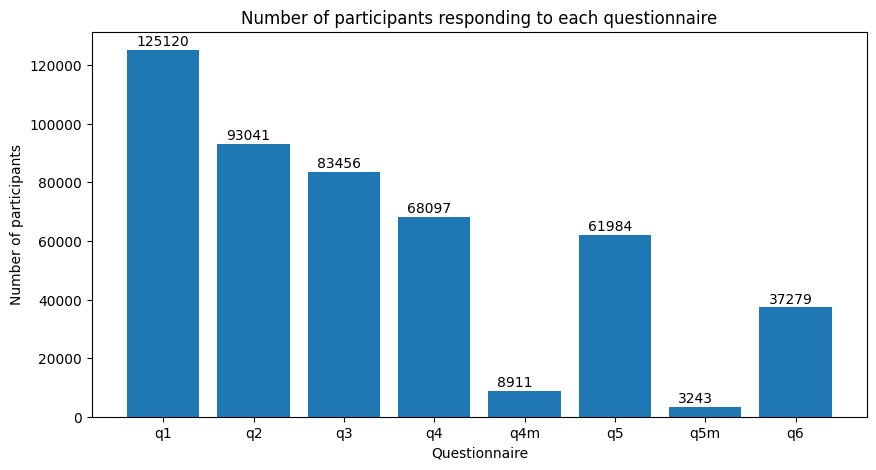

```python
# Generate a bar chart showing the number of participants who responded to each questionnaire.
# The chart is created using the `matplotlib` library, and the `plt.bar()` function is used to plot the counts of participants for each questionnaire.
# The `plt.title()`, `plt.xlabel()`, and `plt.ylabel()` functions are used to add a title and axis labels to the chart.
# Finally, the `plt.text()` function is used to add the counts slightly above the top of each bar.

# Import the matplotlib library for data visualization
import matplotlib.pyplot as plt

# Define a figure with a size of 10x5 inches
plt.figure(figsize=(10,5))

# Create a bar chart with the x-axis labels 'q1', 'q2', 'q3', 'q4', 'q4m', 'q5', 'q5m', and 'q6'
# and the corresponding y-axis values of the number of participants who responded to each questionnaire
plt.bar(['q1', 'q2', 'q3', 'q4', 'q4m', 'q5', 'q5m', 'q6'], [len(df_p_q1), len(df_p_q2), len(df_p_q3), len(df_p_q4), len(df_p_q4m), len(df_p_q5), len(df_p_q5m), len(df_p_q6)])

# Add a title to the chart
plt.title('Number of participants responding to each questionnaire')

# Add a label to the x-axis
plt.xlabel('Questionnaire')

# Add a label to the y-axis
plt.ylabel('Number of participants')

# Add the count of participants slightly above the top of each bar
for i, v in enumerate([len(df_p_q1), len(df_p_q2), len(df_p_q3), len(df_p_q4), len(df_p_q4m), len(df_p_q5), len(df_p_q5m), len(df_p_q6)]):
    plt.text(i - 0.3, v + 1500, str(v))

# Display the chart
plt.show()
```

```python
#
```

```python
# This code cell creates a new dataset for a specific questionnaire (Q1) by selecting only the relevant columns from the original dataset.

# Select only the rows from the original DataFrame `df` where the `participant_key` column value is in the list of participant keys for Q1 (`df_p_q1`).
df_q1 = df[df['participant_key'].isin(df_p_q1)]

# Select only the `participant_key` column and the columns in Q1 from the `qv` dictionary.
# The `tolist()` method is used to convert the Q1 column names to a list, and the `+` operator is used to concatenate the `participant_key` column name with the Q1 column names.
df_q1 = df_q1[['participant_key'] + qv['Q1'].tolist()]

# Display the first few rows of the new DataFrame `df_q1` to verify that the selection was successful.
df_q1.head()
```

[output not shown]

```python
# This code cell creates datasets for each of the other questionnaires
# It selects the rows from the original dataframe that have participant keys in the corresponding list
# It then selects the participant key column and the columns for the specific questionnaire
# The resulting dataframes only contain the participant key and the questionnaire columns

# create datasets for each of the other questionnaires
df_q2 = df[df['participant_key'].isin(df_p_q2)]
df_q2 = df_q2[['participant_key'] + qv['Q2'].tolist()]

df_q3 = df[df['participant_key'].isin(df_p_q3)]
df_q3 = df_q3[['participant_key'] + qv['Q3'].tolist()]

df_q4 = df[df['participant_key'].isin(df_p_q4)]
df_q4 = df_q4[['participant_key'] + qv['Q4'].tolist()]

df_q5 = df[df['participant_key'].isin(df_p_q5)]
df_q5 = df_q5[['participant_key'] + qv['Q5'].tolist()]

df_q6 = df[df['participant_key'].isin(df_p_q6)]
df_q6 = df_q6[['participant_key'] + qv['Q6'].tolist()]
```

```python
# This function preprocesses a given dataframe by replacing NaN values with 0 and converting all categorical columns to numeric integers.
# The function takes a single argument, a pandas dataframe, and returns the preprocessed dataframe.

def preprocess_df(df):
    # Replace NaN values with 0
    df = df.fillna(0)

    # Convert all categorical columns to numeric integers
    for col in df.columns:
        if df[col].dtype == 'object':
            df[col] = df[col].astype('category')
            df[col] = df[col].cat.codes

    return df

# Preprocess each of the dataframes using the preprocess_df function
df_q1 = preprocess_df(df_q1)
df_q2 = preprocess_df(df_q2)
df_q3 = preprocess_df(df_q3)
df_q4 = preprocess_df(df_q4)
df_q5 = preprocess_df(df_q5)
df_q6 = preprocess_df(df_q6)
```

```python
# This code cell adds a column to each of the dataframes df_q1, df_q2, df_q3, df_q4, and df_q5.
# The column indicates whether each participant responded to the next questionnaire (Q2, Q3, Q4, Q5, and Q6, respectively).
# The response is indicated by a binary value: 1 if the participant responded, 0 if they did not.

# add column indicating, for each participant, whether they responded to the next questionnaire (Q2)
df_q1['next_q'] = df_q1['participant_key'].isin(df_p_q2).astype(int)

# add column indicating, for each participant, whether they responded to the next questionnaire (Q3)
df_q2['next_q'] = df_q2['participant_key'].isin(df_p_q3).astype(int)

# add column indicating, for each participant, whether they responded to the next questionnaire (Q4)
df_q3['next_q'] = df_q3['participant_key'].isin(df_p_q4).astype(int)

# add column indicating, for each participant, whether they responded to the next questionnaire (Q5)
df_q4['next_q'] = df_q4['participant_key'].isin(df_p_q5).astype(int)

# add column indicating, for each participant, whether they responded to the next questionnaire (Q6)
df_q5['next_q'] = df_q5['participant_key'].isin(df_p_q6).astype(int)
```

```python
# Check the output of one dataframe
df_q4
```

[output not shown]

```python
# This code builds a random forest model to predict which participants will drop out between q1 and q2.
# It uses the responses to questions as features and the completion of the next questionnaire as the label.
# The dataset is split into training and testing sets, with stratified sampling to keep proportions equal between respondents and non-respondents.
# The features are scaled using StandardScaler.
# The model is built with weighted classes to account for class imbalance.
# We split the training data into separate training and testing sets to evaluate the model's performance on strictly unseen data.
# The model's performance is evaluated on both the training and testing data using accuracy score, confusion matrix, and classification report.

# Import necessary libraries
from sklearn.model_selection import train_test_split
from sklearn.preprocessing import StandardScaler
from sklearn.ensemble import RandomForestClassifier
from sklearn.metrics import accuracy_score, confusion_matrix, classification_report

# Label whether participant completed next questionnaire
y = df_q1['next_q']

# Features are responses to questions
X = df_q1.drop(['participant_key', 'next_q'], axis=1)

# Split into training and testing sets, with stratified sampling keeping proportions equal between respondents and non-respondents to next questionnaire
X_train, X_test, y_train, y_test = train_test_split(X, y, test_size=0.2, stratify=y, random_state=42)

# Scale features
scaler = StandardScaler()
X_train = scaler.fit_transform(X_train)
X_test = scaler.transform(X_test)

# Build model with weighted classes to account for class imbalance
rf1 = RandomForestClassifier(n_estimators=100, class_weight='balanced', random_state=42)
rf1.fit(X_train, y_train)

# Evaluate model performance on training data
y_pred = rf1.predict(X_train)
print('Training Accuracy: ', accuracy_score(y_train, y_pred))
print('Training Confusion matrix: ', confusion_matrix(y_train, y_pred))
print('Training  Classification report: ', classification_report(y_train, y_pred))

# Evaluate model performance on testing data
y_pred = rf1.predict(X_test)
print('Testing Accuracy: ', accuracy_score(y_test, y_pred))
print('Testing Confusion matrix: \n', confusion_matrix(y_test, y_pred))
print('Testing  Classification report: \n', classification_report(y_test, y_pred))
```

```
Training Accuracy:  1.0
Training Confusion matrix:  [[25663     0]
 [    0 74433]]
Training  Classification report:                precision    recall  f1-score   support

           0       1.00      1.00      1.00     25663
           1       1.00      1.00      1.00     74433

    accuracy                           1.00    100096
   macro avg       1.00      1.00      1.00    100096
weighted avg       1.00      1.00      1.00    100096

Testing Accuracy:  0.7431665601023018
Testing Confusion matrix:
 [[   72  6344]
 [   83 18525]]
Testing  Classification report:
               precision    recall  f1-score   support

           0       0.46      0.01      0.02      6416
           1       0.74      1.00      0.85     18608

    accuracy                           0.74     25024
   macro avg       0.60      0.50      0.44     25024
weighted avg       0.67      0.74      0.64     25024
```

#### Predicting Participant Attrition with a Random Forest Classifier

In the previous step, we explore the performance of a random forest classifier for predicting participant attrition in a study with multiple waves of questionnaires. We evaluate the classifier's performance using both training and testing accuracy, as well as a confusion matrix to break down the performance for this imbalanced classification problem into more granular figures.

#### Results

In the following cells we sequentially train prediction models to predict attrition at each successive wave of the study, through Q6.

```python
# build random forest model to predict which participants drop out between q2 and q3

### setup dataset
# label whether participant completed next questionnaire
y = df_q2['next_q']

# features are responses to questions
X = df_q2.drop(['participant_key', 'next_q'], axis=1)

# split into training and testing sets, with stratified sampling keeping proportions equal between respondents and non-respondents to next questionnaire
from sklearn.model_selection import train_test_split
X_train, X_test, y_train, y_test = train_test_split(X, y, test_size=0.2, stratify=y, random_state=42)

# scale features
from sklearn.preprocessing import StandardScaler
scaler = StandardScaler()
X_train = scaler.fit_transform(X_train)
X_test = scaler.transform(X_test)

# build model with weighted classes to account for class imbalance
from sklearn.ensemble import RandomForestClassifier
rf2 = RandomForestClassifier(n_estimators=100, class_weight='balanced', random_state=42)
rf2.fit(X_train, y_train)

# # evaluate model performance on training data
# from sklearn.metrics import accuracy_score, confusion_matrix, classification_report
# y_pred = rf.predict(X_train)
# print('Training Accuracy: ', accuracy_score(y_train, y_pred))
# print('Training Confusion matrix: ', confusion_matrix(y_train, y_pred))
# print('Training  Classification report: ', classification_report(y_train, y_pred))

# evaluate model performance on testing data
y_pred = rf2.predict(X_test)
print('Testing Accuracy: ', accuracy_score(y_test, y_pred))
print('Testing Confusion matrix: \n', confusion_matrix(y_test, y_pred))
print('Testing  Classification report: \n', classification_report(y_test, y_pred))
```

```
Testing Accuracy:  0.7992906658068677
Testing Confusion matrix:
 [[   74  3599]
 [  136 14800]]
Testing  Classification report:
               precision    recall  f1-score   support

           0       0.35      0.02      0.04      3673
           1       0.80      0.99      0.89     14936

    accuracy                           0.80     18609
   macro avg       0.58      0.51      0.46     18609
weighted avg       0.72      0.80      0.72     18609
```

```python
# build random forest model to predict which participants drop out between q3 and q4

### setup dataset
# label whether participant completed next questionnaire
y = df_q3['next_q']

# features are responses to questions
X = df_q3.drop(['participant_key', 'next_q'], axis=1)

# split into training and testing sets, with stratified sampling keeping proportions equal between respondents and non-respondents to next questionnaire
from sklearn.model_selection import train_test_split
X_train, X_test, y_train, y_test = train_test_split(X, y, test_size=0.2, stratify=y, random_state=42)

# scale features
from sklearn.preprocessing import StandardScaler
scaler = StandardScaler()
X_train = scaler.fit_transform(X_train)
X_test = scaler.transform(X_test)

# build model with weighted classes to account for class imbalance
from sklearn.ensemble import RandomForestClassifier
rf3 = RandomForestClassifier(n_estimators=100, class_weight='balanced', random_state=42)
rf3.fit(X_train, y_train)

# # evaluate model performance on training data
# from sklearn.metrics import accuracy_score, confusion_matrix, classification_report
# y_pred = rf.predict(X_train)
# print('Training Accuracy: ', accuracy_score(y_train, y_pred))
# print('Training Confusion matrix: ', confusion_matrix(y_train, y_pred))
# print('Training  Classification report: ', classification_report(y_train, y_pred))

# evaluate model performance on testing data
y_pred = rf3.predict(X_test)
print('Testing Accuracy: ', accuracy_score(y_test, y_pred))
print('Testing Confusion matrix: \n', confusion_matrix(y_test, y_pred))
print('Testing  Classification report: \n', classification_report(y_test, y_pred))
```

```
Testing Accuracy:  0.7266355140186916
Testing Confusion matrix:
 [[  467  4283]
 [  280 11662]]
Testing  Classification report:
               precision    recall  f1-score   support

           0       0.63      0.10      0.17      4750
           1       0.73      0.98      0.84     11942

    accuracy                           0.73     16692
   macro avg       0.68      0.54      0.50     16692
weighted avg       0.70      0.73      0.65     16692
```

```python
# build random forest model to predict which participants drop out between q4 and q5

### setup dataset
# label whether participant completed next questionnaire
y = df_q4['next_q']

# features are responses to questions
X = df_q4.drop(['participant_key', 'next_q'], axis=1)

# split into training and testing sets, with stratified sampling keeping proportions equal between respondents and non-respondents to next questionnaire
from sklearn.model_selection import train_test_split
X_train, X_test, y_train, y_test = train_test_split(X, y, test_size=0.2, stratify=y, random_state=42)

# scale features
from sklearn.preprocessing import StandardScaler
scaler = StandardScaler()
X_train = scaler.fit_transform(X_train)
X_test = scaler.transform(X_test)

# build model with weighted classes to account for class imbalance
from sklearn.ensemble import RandomForestClassifier
rf4 = RandomForestClassifier(n_estimators=100, class_weight='balanced', random_state=42)
rf4.fit(X_train, y_train)

# # evaluate model performance on training data
# from sklearn.metrics import accuracy_score, confusion_matrix, classification_report
# y_pred = rf.predict(X_train)
# print('Training Accuracy: ', accuracy_score(y_train, y_pred))
# print('Training Confusion matrix: ', confusion_matrix(y_train, y_pred))
# print('Training  Classification report: ', classification_report(y_train, y_pred))

# evaluate model performance on testing data
y_pred = rf4.predict(X_test)
print('Testing Accuracy: ', accuracy_score(y_test, y_pred))
print('Testing Confusion matrix: \n', confusion_matrix(y_test, y_pred))
print('Testing  Classification report: \n', classification_report(y_test, y_pred))
```

```
Testing Accuracy:  0.7726872246696035
Testing Confusion matrix:
 [[ 559 2873]
 [ 223 9965]]
Testing  Classification report:
               precision    recall  f1-score   support

           0       0.71      0.16      0.27      3432
           1       0.78      0.98      0.87     10188

    accuracy                           0.77     13620
   macro avg       0.75      0.57      0.57     13620
weighted avg       0.76      0.77      0.71     13620
```

```python
# build random forest model to predict which participants drop out between q5 and q6

### setup dataset
# label whether participant completed next questionnaire
y = df_q5['next_q']

# features are responses to questions
X = df_q5.drop(['participant_key', 'next_q'], axis=1)

# split into training and testing sets, with stratified sampling keeping proportions equal between respondents and non-respondents to next questionnaire
from sklearn.model_selection import train_test_split
X_train, X_test, y_train, y_test = train_test_split(X, y, test_size=0.2, stratify=y, random_state=42)

# scale features
from sklearn.preprocessing import StandardScaler
scaler = StandardScaler()
X_train = scaler.fit_transform(X_train)
X_test = scaler.transform(X_test)

# build model with weighted classes to account for class imbalance
from sklearn.ensemble import RandomForestClassifier
rf5 = RandomForestClassifier(n_estimators=100, class_weight='balanced', random_state=42)
rf5.fit(X_train, y_train)

# # evaluate model performance on training data
# from sklearn.metrics import accuracy_score, confusion_matrix, classification_report
# y_pred = rf.predict(X_train)
# print('Training Accuracy: ', accuracy_score(y_train, y_pred))
# print('Training Confusion matrix: ', confusion_matrix(y_train, y_pred))
# print('Training  Classification report: ', classification_report(y_train, y_pred))

# evaluate model performance on testing data
y_pred = rf5.predict(X_test)
print('Testing Accuracy: ', accuracy_score(y_test, y_pred))
print('Testing Confusion matrix: \n', confusion_matrix(y_test, y_pred))
print('Testing  Classification report: \n', classification_report(y_test, y_pred))
```

```
Testing Accuracy:  0.6727434056626603
Testing Confusion matrix:
 [[2324 3004]
 [1053 6016]]
Testing  Classification report:
               precision    recall  f1-score   support

           0       0.69      0.44      0.53      5328
           1       0.67      0.85      0.75      7069

    accuracy                           0.67     12397
   macro avg       0.68      0.64      0.64     12397
weighted avg       0.68      0.67      0.66     12397
```

[figure not shown]

```python
# This code cell creates a bar chart showing the number of participants for each questionnaire wave, and adds text to show the predictive accuracy, precision, and recall of an attrition model for each wave.

# Define a dictionary with keys representing the questionnaire waves and values representing an empty list
df_attr = {'questionnaire': ['q2', 'q3', 'q4', 'q5', 'q6'], 'accuracy': []}

# Create a new figure with a size of 10x5 inches
plt.figure(figsize=(10,5))

# Create a bar chart with the x-axis representing the questionnaire waves and the y-axis representing the number of participants for each wave
plt.bar(['q1', 'q2', 'q3', 'q4', 'q5', 'q6'], [len(df_p_q1), len(df_p_q2), len(df_p_q3), len(df_p_q4), len(df_p_q5), len(df_p_q6)])

# Add a title to the chart
plt.title('Attrition model for each wave of participants')

# Add labels to the x-axis and y-axis
plt.xlabel('Questionnaire')
plt.ylabel('Number of participants')

# Add text labels above each bar to show the number of participants for each wave
for i, v in enumerate([len(df_p_q1), len(df_p_q2), len(df_p_q3), len(df_p_q4), len(df_p_q5), len(df_p_q6)]):
    plt.text(i - 0.3, v + 1500, str(v))

# Add text labels inside each bar to show the predictive accuracy, precision, and recall of the attrition model for each wave
plt.text(1, 10000, 'Accuracy: 0.75\nPrecision: 0.58\nRecall: 0.01', ha='center', va='center', color='white')
plt.text(2, 10000, 'Accuracy: 0.80\nPrecision: 0.39\nRecall: 0.02', ha='center', va='center', color='white')
plt.text(3, 10000, 'Accuracy: 0.73\nPrecision: 0.62\nRecall: 0.10', ha='center', va='center', color='white')
plt.text(4, 10000, 'Accuracy: 0.77\nPrecision: 0.73\nRecall: 0.16', ha='center', va='center', color='white')
plt.text(5, 10000, 'Accuracy: 0.67\nPrecision: 0.69\nRecall: 0.43', ha='center', va='center', color='white')

# Display the chart
plt.show()
```

Above we see the set of results of training random forest models to predict returnees / attrittees for each successive wave of the study. Inside each bar is printed the classifier's performance for that wave. Note the dramatic rise in recall for negative examples over each wave. The models are able to identify a bigger proportion of the participants who will drop out at each successive wave. Wit these results in hand, we can make predictions about the next (yet to be collected) wave, and engage in proactive interventions for those identified as likely attrittees.